# Project 01.01 Report

Annika Hein, Amanda Janzen, Nicolai Laufer, Niklas Schwan

25/06/2019

# Introduction

In this project we tried to identify genetic interactions and their effects on several Glioblastoma multiforme (GBM) cell lines.

GBM is a fast growing, malignant brain tumor classified as a grade IV cancer by the World Health Organisation (WHO). It represents about 15% of all brain tumors and most commonly develops in adults aged 45-70. We chose GBM because it falls in the category of cancers with poor diagnosis and also has no effective long-term treatments, which leads to a survival rate of less than 15 months, according to the TCGA (The Cancer Genome Atlas Research Network).

The identification of genomic interactions and their effect on cancer cell survival is very important for the search after better treatments. Its concept is tied to the fact that cancer is a product of accumulated genomic defects (mutations, copy number changes, etc.). There are a handful of genes that drive the process of oncogenesis, these are called *driver mutations* (DM), all other mutations that do not really have an impact on the oncogenisis are called *passenger mutations*.

The driver mutations are normally highly essential genes for all cells in the human body, making them a bad target for anti-cancer drugs, for they would shut down all cells, not just cancer cells. The alternative to this targeting problem is to find genes that are linked with the driving mutations in the cancer cells, but not in the normal cells. Ideally, the targeting of these so called *second site targets* (SST) would cause the cancer cells to shut down and stop proliferating, while the normal cells would not be subjected to any changes.

Our aim in this project was to find the driver mutations in GBM throughout all cell lines in our data set, compare them to the literature and investigate if there is a dependency between them and any second site targets. In the end the aim was to find a model where we could possibly predict either the expression, copy number, CERES score or the probability of stopping cell proliferation targeting one specific gene. The CERES score is a measure of how essential/important a particular gene is for cell survival. It reflects whether upon knocking down that genes the cell reduces or increases its proliferation or has no effect. Smaller values refer to higher essentiality.

# Data cleanup

Once we downloaded the data, we first removed all data that did not have to do with Glioblastoma and made the cell line identifiers be the rownames in the annotation.

```r
allDepMapData = readRDS("C:\\Users\\nikla\\Documents\\R\\bioinfoproject\\project-01-group-01\\AllDepMapData.RDS")
brain.anno = allDepMapData$annotation[allDepMapData$annotation$Subtype.Disease == "Glioblastoma", ]
rownames(brain.anno) = brain.anno$DepMap_ID
brain.anno = brain.anno[, -1]
```

The next step was to remove all cell lines that were irrelevant to our project from all the other matrices (expression, copy number, relevant mutations, ceres and probability).

Package “operators” needed.

```r
cell.lines = dput(rownames(brain.anno))
```

```
## c("ACH-000036", "ACH-000040", "ACH-000075", "ACH-000098", "ACH-000208",
## "ACH-000215", "ACH-000137", "ACH-000152", "ACH-000591", "ACH-000673",
## "ACH-000231", "ACH-000244", "ACH-000760", "ACH-000368", "ACH-000376",
## "ACH-000445", "ACH-000464", "ACH-000469", "ACH-000479", "ACH-000570",
## "ACH-000571", "ACH-000623", "ACH-000631", "ACH-000738", "ACH-000756",
## "ACH-000819", "ACH-000128", "ACH-000887")
```

```r
exp.clean = allDepMapData$expression[, -which(colnames(allDepMapData$expression) %!in% cell.lines)]
copy.clean = allDepMapData$copynumber[, -which(colnames(allDepMapData$copynumber) %!in% cell.lines)]
relevant.mutations = subset(allDepMapData$mutation, names(allDepMapData$mutation) %in% cell.lines)
ceres.clean = allDepMapData$kd.ceres[, -which(colnames(allDepMapData$kd.ceres) %!in% cell.lines)]
prob.clean = allDepMapData$kd.prob[, -which(colnames(allDepMapData$kd.prob) %!in% cell.lines)]
```

Putting gene names and cell lines in alphabetical order.

```r
ceres.clean = ceres.clean[order(rownames(ceres.clean)), order(colnames(ceres.clean))]
prob.clean = prob.clean[order(rownames(prob.clean)), order(colnames(prob.clean))]
exp.clean = exp.clean[order(rownames(exp.clean)), order(colnames(exp.clean))]
copy.clean = copy.clean[order(rownames(copy.clean)), order(colnames(copy.clean))]
```

After isolating the relevant cell lines, we checked our matrices for NA values, outliers as well as values x = 0 and removed them.

1. Checking for NA values in all matrices.

```r
sum(is.na(ceres.clean))
```

```
## [1] 0
```

```r
sum(is.na(prob.clean))
```

```
## [1] 0
```

```r
sum(is.na(copy.clean))
```

```
## [1] 1780
```

```r
sum(is.na(exp.clean))
```

```
## [1] 0
```

```r
sum(is.na(relevant.mutations))
```

```
## [1] 0
```

The function sum() was used to show how many NA values were in each matrix.

- ceres.clean -> 0
- prob.clean -> 0
- copy.clean -> 1780
- exp.clean -> 0
- relevant.mutations -> 0, but looking directly in the matrix we can see several NA values.
2. Removing NA values from copy number matrix.

```r
copy.clean = copy.clean[-which(apply(copy.clean, 1, function(x) {sum(is.na(x))}) > 0), ]
sum(is.na(copy.clean))
```

```
## [1] 0
```

3. Scan for outliers via boxplots.

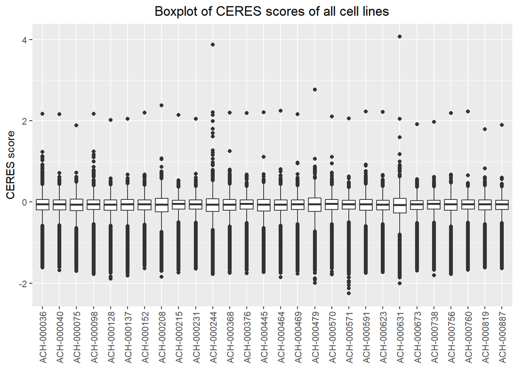

```r
library(reshape2)
library(ggplot2)
ceres.boxplot = ggplot(melt(ceres.clean), aes(x = variable, y = value)) + geom_boxplot() + theme(axis.text.x  = element_text(angle=90, vjust=0.5), plot.title = element_text(hjust = 0.5)) + ggtitle(paste0("Boxplot of CERES scores of all cell lines")) + ylab("CERES score") + xlab(NULL)
ceres.boxplot
```

4. Then we checked all matrices for containing values x = 0.

```r
sum(ceres.clean == 0)
```

```
## [1] 28
```

```r
sum(prob.clean == 0)
```

```
## [1] 80
```

```r
sum(copy.clean == 0)
```

```
## [1] 0
```

```r
sum(exp.clean == 0)
```

```
## [1] 644705
```

We then decided to generate the matrices with and without x = 0 values.

Matrices with x = 0 vaues:

```r
dim(copy.clean) == dim(exp.clean)
```

```
## [1] FALSE  TRUE
```

```r
gene.data.co = c(rownames(copy.clean))
gene.data.ex = c(rownames(exp.clean))
exp.clean = exp.clean[-which(rownames(exp.clean) %!in% gene.data.co),]
copy.clean = copy.clean[-which(rownames(copy.clean) %!in% gene.data.ex),]
genes.clean = rownames(exp.clean)
ceres.clean = ceres.clean[-which(rownames(ceres.clean) %!in% genes.clean),]
prob.clean = prob.clean[-which(rownames(prob.clean) %!in% genes.clean),]
genes.clean = rownames(ceres.clean)
exp.clean = exp.clean[-which(rownames(exp.clean) %!in% genes.clean),]
copy.clean = copy.clean[-which(rownames(copy.clean) %!in% genes.clean),]
rm(gene.data.co)
rm(gene.data.ex)
```

The final dimensions: 16970x28

For the matrices without x = 0 values, we removed those:

```r
exp.clean.w0 <- exp.clean[!(apply(exp.clean, 1, function(y) any(y == 0))),]
sum(exp.clean.w0 == 0)
```

```
## [1] 0
```

```r
copy.clean.w0 <- copy.clean[!(apply(copy.clean, 1, function(y) any(y == 0))),]
sum(copy.clean.w0 == 0)
```

```
## [1] 0
```

```r
ceres.clean.w0 <- ceres.clean[!(apply(ceres.clean, 1, function(y) any(y == 0))),]
sum(ceres.clean.w0 == 0)
```

```
## [1] 0
```

```r
prob.clean.w0 <- prob.clean[!(apply(prob.clean, 1, function(y) any(y == 0))),]
sum(prob.clean.w0 == 0)
```

```
## [1] 0
```

Next we compared gene data availability to ensure all matrices have the same dimension.

```r
dim(copy.clean.w0) == dim(exp.clean.w0)
```

```
## [1] FALSE  TRUE
```

```r
gene.data.ex = c(rownames(exp.clean.w0))
copy.clean.w0 = copy.clean.w0[-which(rownames(copy.clean.w0) %!in% gene.data.ex),]
genes.clean.w0 = rownames(exp.clean.w0)
ceres.clean.w0 = ceres.clean.w0[-which(rownames(ceres.clean.w0) %!in% genes.clean.w0),]
prob.clean.w0 = prob.clean.w0[-which(rownames(prob.clean.w0) %!in% genes.clean.w0),]
genes.clean.w0 = rownames(prob.clean.w0)
exp.clean.w0 = exp.clean.w0[-which(rownames(exp.clean.w0) %!in% genes.clean.w0),]
copy.clean.w0 = copy.clean.w0[-which(rownames(copy.clean.w0) %!in% genes.clean.w0),]
ceres.clean.w0 = ceres.clean.w0[-which(rownames(ceres.clean.w0) %!in% genes.clean.w0),]
rm(gene.data.ex)
```

The final dimension: 11545x28

Make all data nominal in the annotation.

```r
brain.anno$CCLE_Name = factor(brain.anno$CCLE_Name)
brain.anno$Aliases = factor(brain.anno$Aliases)
brain.anno$Primary.Disease = factor(brain.anno$Primary.Disease)
brain.anno$Subtype.Disease = factor(brain.anno$Subtype.Disease)
brain.anno$Subtype.Gender = factor(brain.anno$Gender)
brain.anno$Subtype.Source = factor(brain.anno$Source)
```

# Data visualization

## Identification of driving mutations

In order to find all most commonly mutated genes among all relevant cell lines, we merged all mutation matrices.

```r
relevant.mutations.combi = do.call(rbind, lapply(which(names(allDepMapData$mutation) %in% cell.lines), function(a) allDepMapData$mutation[[a]]))
common.genes = as.matrix(table(c(relevant.mutations.combi$Hugo_Symbol)))
```

Next we plotted all the mutated genes as well as the ten most frequent ones by using barplots. The genes were sorted manually according to their frequency of being mutated among our cell lines.

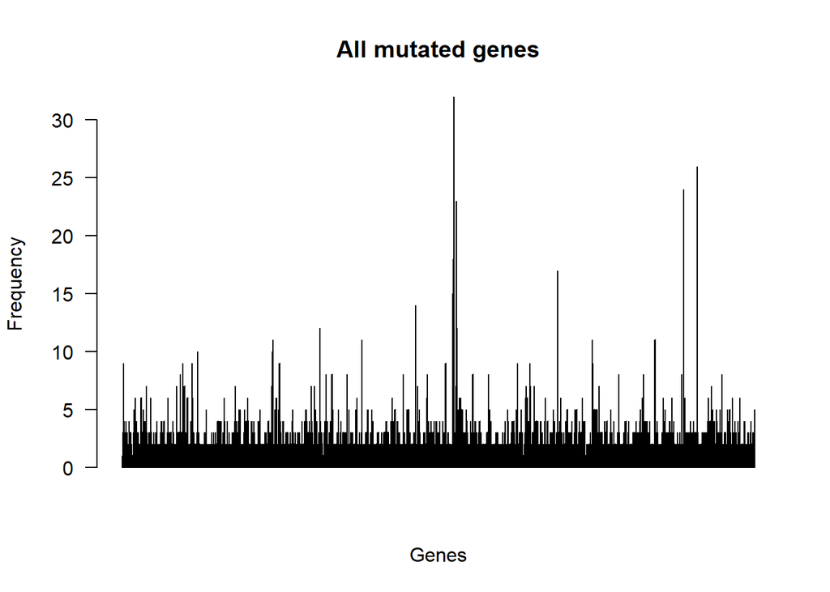

```r
common.genes = as.matrix(common.genes)
barplot(common.genes, beside = T, names.arg = NULL,  ylab = "Frequency", xlab = "Genes", main = "All mutated genes", las = 2)
```

```r
common.genes.c = subset(common.genes, common.genes >11)
common.genes.c = common.genes.c[c(6, 11, 10, 7, 4, 9, 3, 2, 1, 8),]
common.genes.c
```

```
## MT-ND5    TTN   TP53  MUC16 MT-CYB   PTEN MT-CO1   LIPE    FLG   MUC4
##     32     26     24     23     18     17     15     14     12     12
```

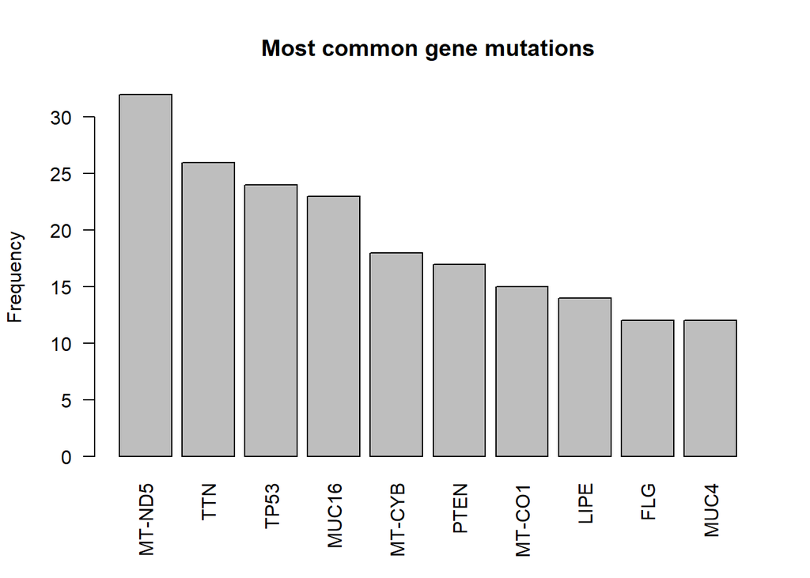

```r
barplot_commongenes <- barplot(common.genes.c, beside = T, names.arg = rownames(common.genes.c), ylab = "Frequency", main = "Most common gene mutations", las = 2)
```

### Commonly mutated genes

**1. MT-ND5:** (32 mutations) Mitochondrial gene, which encodes NADH-ubiquinone oxidoreductase chain 5 (ND5). ND5 is a subunit of NADH dehydrogenase, the largest complex of the electron transport chain. Variations are associated with mitochondrial encephalomypathy, stroke-like episodes as well as Leighs syndrome and Leber’s hereditary optic neuropathy (Zhou et al., 2019; McKenzie and Duchen, 2016).

**2. TTN:** (26 mutations) Gene, which encodes for Titin/Connectin, which is crucial for myofibrillar elasticity and integrity. Variations are associated with several forms of myopathy (Ceyhan-Birsoy et al., 2013; Gerull et al., 2002).

**3. TP53:** (24 mutations) Tumor suppressing gene, which encodes for p53, which plays a role in regulation or progression through the cell cycle, apoptosis and genomic stability. Variations are directly associated with cancer formation (Takami et al., 2015).

**4. MUC16:** (23 mutations) Gene, which encodes for the cancer antigen CA-125/mucin 16, a highly glycosylated protein. It has found application as tumor marker, since it plays a role in tumor proliferation as a suppressor of the anti-tumor immune response (Scholler and Urban, 2007).

**5. MT-CYB:** (18 mutations) Gene, which encodes for cytochrome b, a subunit of the respiratory chain protein ubiquinol cytochrome c reductase. Variations result in mitochondrial deficiencies and associated disorders, including exericise intolerance (Carossa et al., 2014).

**6. PTEN:** (17 mutations) Tumor suppressing gene, which encodes for phosphatase and tensin homolog. The enzyme is involved in regulation of cell growth and survival. Variations result in increased cell proliferation and in evasion of cell death. Frequent genetic inactivation of PTEN occurs in glioblastoma (Cantley and Neel, 1999).

**7. Other mutations:** (10096)

### Comparison with literature

According to scientific papers (McLendon et al., 2008; Brennan et al., 2013), the most prominent driving mutations for GBM are:

1. EGFR
2. CDKN2A
3. ARF
4. TP53
5. PTEN

Our result does not confirm the observations made in the literature, but that is not suprising since our dataset is very small in comparison to scientific investigations. However, in TP53 and PTEN we managed to find two of those five most prominent genetic alterations in GBM.

## Data distribution

We visualized the gene’s distribution in all matrices using heatmaps.

Packages used: pheatmap, grid

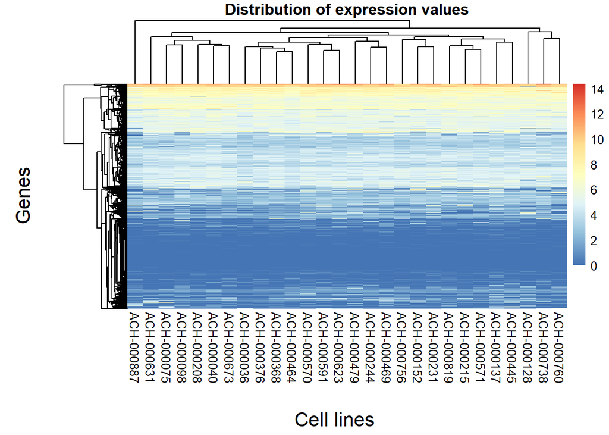

```r
setHook("grid.newpage", function() pushViewport(viewport(x=1,y=1,width=0.9, height=0.9, name="vp", just=c("right","top"))), action="prepend")
pheatmap(exp.clean, main = "Distribution of expression values",  show_rownames = F)
setHook("grid.newpage", NULL, "replace")
grid.text("Cell lines", y=-0.07, gp=gpar(fontsize=16))
grid.text("Genes", x=-0.07, rot=90, gp=gpar(fontsize=16))
```

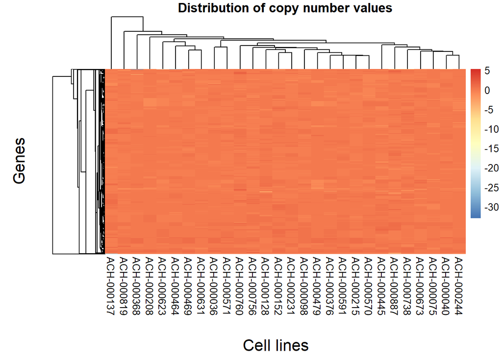

```r
setHook("grid.newpage", function() pushViewport(viewport(x=1,y=1,width=0.9, height=0.9, name="vp", just=c("right","top"))), action="prepend")
pheatmap(copy.clean, main = "Distribution of copy number values", show_rownames = F)
setHook("grid.newpage", NULL, "replace")
grid.text("Cell lines", y=-0.07, gp=gpar(fontsize=16))
grid.text("Genes", x=-0.07, rot=90, gp=gpar(fontsize=16))
```

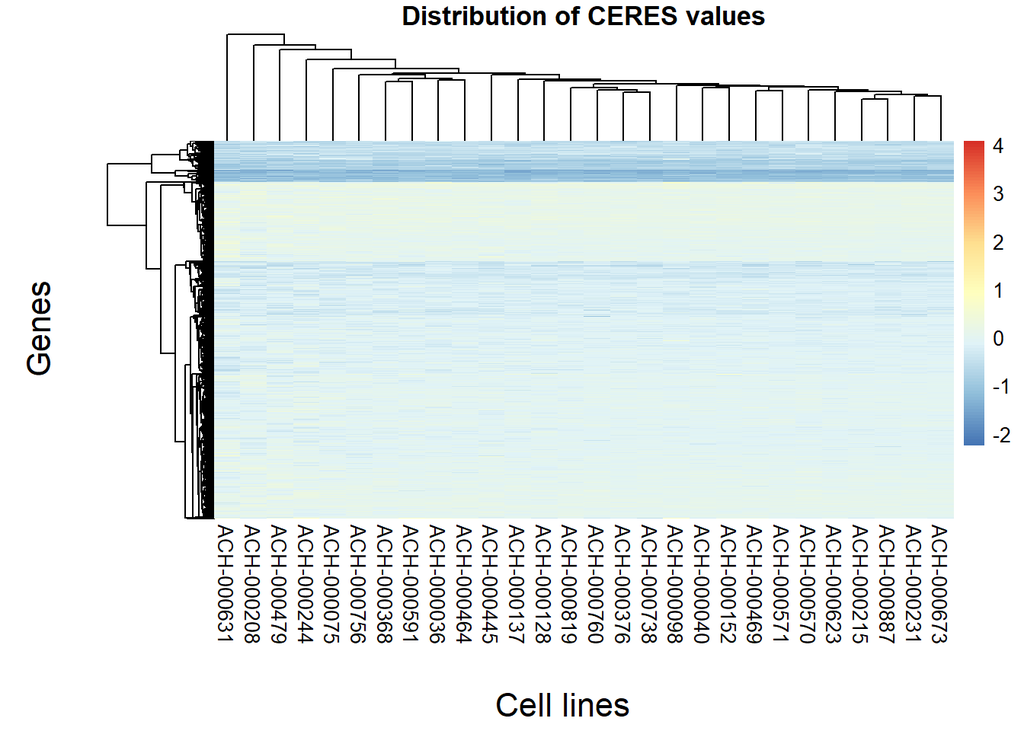

```r
setHook("grid.newpage", function() pushViewport(viewport(x=1,y=1,width=0.9, height=0.9, name="vp", just=c("right","top"))), action="prepend")
pheatmap(ceres.clean, main = "Distribution of CERES values", show_rownames = F)
setHook("grid.newpage", NULL, "replace")
grid.text("Cell lines", y=-0.07, gp=gpar(fontsize=16))
grid.text("Genes", x=-0.07, rot=90, gp=gpar(fontsize=16))
```

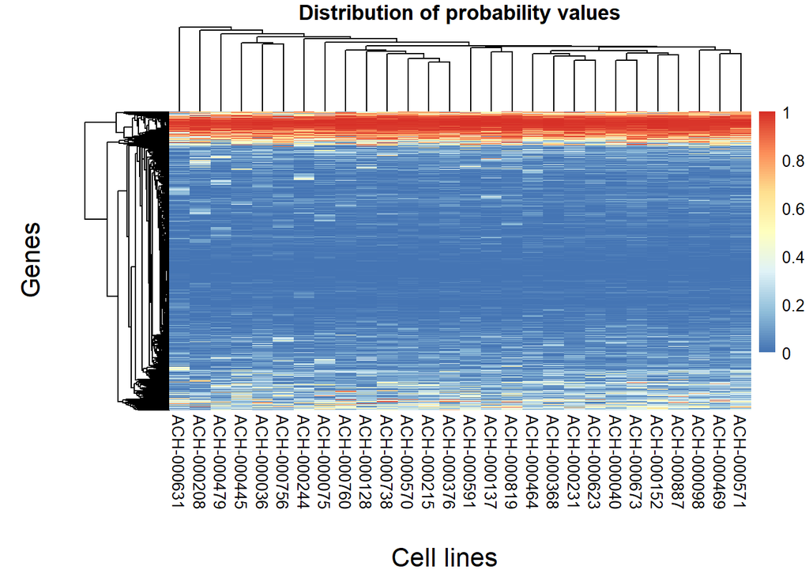

```r
setHook("grid.newpage", function() pushViewport(viewport(x=1,y=1,width=0.9, height=0.9, name="vp", just=c("right","top"))), action="prepend")
pheatmap(prob.clean, main = "Distribution of probability values", show_rownames = F)
setHook("grid.newpage", NULL, "replace")
grid.text("Cell lines", y=-0.07, gp=gpar(fontsize=16))
grid.text("Genes", x=-0.07, rot=90, gp=gpar(fontsize=16))
```

# Data reduction

In order to just continue with the necessary data, we need to reduce our dataset. Since we already determined our most common mutations, we now manually isolate all cell lines from the mutation matrix, which contain one/all of those specific mutations. Since only PTEN, MUC-16 and TP53 are directly associated with the development of cancer, we decided wot continue working with these three driving mutations (DM). Our aim is to identify all other genes that were also mutated in the presence of these specific DMs. Since there were a few thousand mutated genes for each DM, the ones with “IsDeleterious = TRUE” were extracted.

Package dplyr needed for this step

```r
mutations.tp53 = rbind(relevant.mutations$`ACH-000036`,relevant.mutations$`ACH-000040`, relevant.mutations$`ACH-000098`, relevant.mutations$`ACH-000208`, relevant.mutations$`ACH-000215`, relevant.mutations$`ACH-000137`, relevant.mutations$`ACH-000152`, relevant.mutations$`ACH-000591`, relevant.mutations$`ACH-000673`, relevant.mutations$`ACH-000231`, relevant.mutations$`ACH-000368`, relevant.mutations$`ACH-000376`, relevant.mutations$`ACH-000445`, relevant.mutations$`ACH-000464`, relevant.mutations$`ACH-000469`, relevant.mutations$`ACH-000570`, relevant.mutations$`ACH-000571`, relevant.mutations$`ACH-000623`, relevant.mutations$`ACH-000673`, relevant.mutations$`ACH-000738`, relevant.mutations$`ACH-000756`, relevant.mutations$`ACH-000819`, relevant.mutations$`ACH-000128`)
mutations.tp53 = select(mutations.tp53, c(2,21, 36))
mutations.tp53 = subset(mutations.tp53, mutations.tp53$isDeleterious == "TRUE")

mutations.muc16 = rbind(relevant.mutations$`ACH-000036`, relevant.mutations$`ACH-000137`, relevant.mutations$`ACH-000152`, relevant.mutations$`ACH-000208`, relevant.mutations$`ACH-000231`, relevant.mutations$`ACH-000368`, relevant.mutations$`ACH-000376`, relevant.mutations$`ACH-000464`, relevant.mutations$`ACH-000571`, relevant.mutations$`ACH-000738`, relevant.mutations$`ACH-000756`, relevant.mutations$`ACH-000819`)
mutations.muc16 = select(mutations.muc16, c(2,21, 36))
mutations.muc16 = subset(mutations.muc16, mutations.muc16$isDeleterious == "TRUE")

mutations.pten = rbind(relevant.mutations$`ACH-000036`, relevant.mutations$`ACH-000040`, relevant.mutations$`ACH-000075`, relevant.mutations$`ACH-000208`, relevant.mutations$`ACH-000215`, relevant.mutations$`ACH-000137`, relevant.mutations$`ACH-000152`, relevant.mutations$`ACH-000231`, relevant.mutations$`ACH-000244`, relevant.mutations$`ACH-000760`, relevant.mutations$`ACH-000376`, relevant.mutations$`ACH-000464`, relevant.mutations$`ACH-000570`, relevant.mutations$`ACH-000571`, relevant.mutations$`ACH-000623`, relevant.mutations$`ACH-000128`)
mutations.pten = select(mutations.pten, c(2,21, 36))
mutations.pten = subset(mutations.pten, mutations.pten$isDeleterious == "TRUE")
```

Next we extracted those remaining genes for each DM from the CERES matrix in order to continue working with just them.

```r
list.tp53.genes = unique(subset(mutations.tp53))
genes.tp53 <- c(list.tp53.genes$Hugo_Symbol)
ceres.tp53.genes <- ceres.clean[which(rownames(ceres.clean) %in% genes.tp53),]

list.muc16.genes = unique(subset(mutations.muc16))
genes.muc16 <- c(list.muc16.genes$Hugo_Symbol)
ceres.muc16.genes <- ceres.clean[which(rownames(ceres.clean) %in% genes.muc16),]

list.pten.genes = unique(subset(mutations.pten))
genes.pten <- c(list.pten.genes$Hugo_Symbol)
ceres.pten.genes <- ceres.clean[which(rownames(ceres.clean) %in% genes.pten),]
```

# Statistical tests

Our next goal is to determine whether there is a correlation between the presence of a specific DM and the essentiality of a second mutated gene, which then might be a potential second-site-target (SST).

## Checking data distribution in order to determine which correlation test to apply

Parametric correlation test (e.g. Pearson correlation) needs normally distributed data. If that is not the case, we need to apply non-parametric tests (e.g. Spearman correlation or Wilcoxon Rank sum test).

Methods to determine the type of distribution: qq-plots (visual determination), Shapiro-Wilk-test.

- Exemplary qq-plot of CERES scores of all genes of cell line ACH-000036

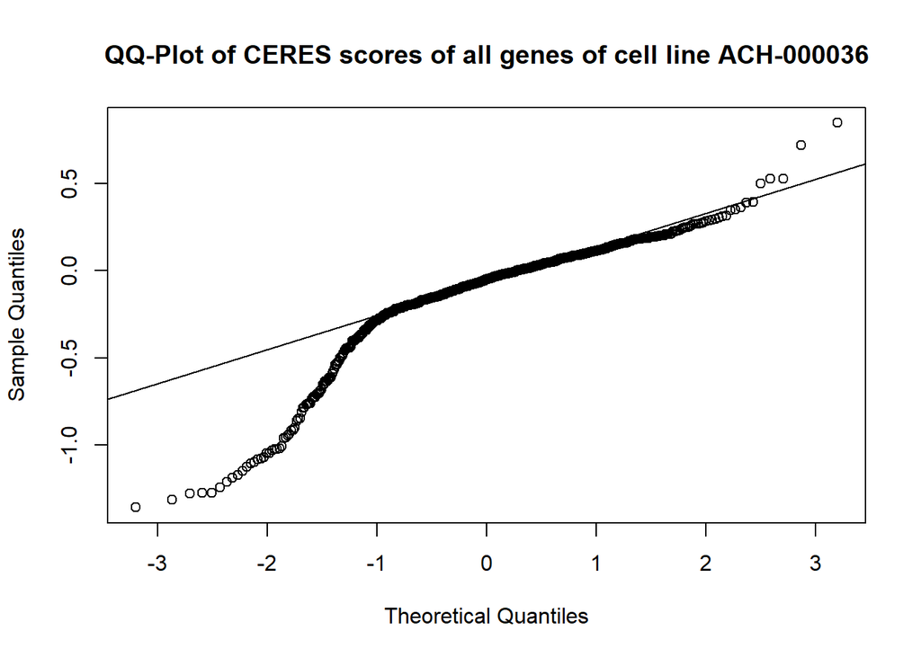

```r
qqnorm(ceres.tp53.genes$`ACH-000036`, main = "QQ-Plot of CERES scores of all genes of cell line ACH-000036")
qqline(ceres.tp53.genes$`ACH-000036`, datax = FALSE, distribution = qnorm,
        probs = c(0.25, 0.75), qtype = 7)
```

Observation: qq-plot shows curve that deviates from a linear curve. Conclusion: CERES scores are not normally distributed.

## Shapiro-Wilk-Test (exemplary for one cell line)

H0 hypothesis: data is normally distributed H1 hypothesis: data is not normally distributed

```r
shapiro.test(ceres.tp53.genes$`ACH-000036`)
```

```
##
##  Shapiro-Wilk normality test
##
## data:  ceres.tp53.genes$`ACH-000036`
## W = 0.85504, p-value < 2.2e-16
```

### Results:

Data: ceres.tp53.genes$ACH-000036 W = 0.85504, p-value < 2.2e-16

### Interpretation:

p-value < 0.05 –> H0 hypothesis can be rejected and H1 is statistically proven –> CERES scores of all genes of cell line ACH-000036 are not normally distributed

## Shapiro-Wilk-Test: using apply-function to determine the distribution of all cell lines

Creating a matrix that contains all mutated genes of cell lines

```r
ceres.allDM.genes=rbind(ceres.tp53.genes, ceres.pten.genes, ceres.muc16.genes)
lapply(ceres.allDM.genes,shapiro.test)
```

### Results:

All cell lines show p-values < 0.05 –> no normally distributed data

## Performing non-parametric tests to determine the correlation of the mutated genes to the DMs in order to find potential SSTs

### Spearman correlation

We used this test to correlate the CERES scores of every gene across all cell lines belonging to one specific DM to the specific DM.

In order for this to work we transposed all matrices to make cell lines rows and genes columns.

```r
t(ceres.tp53.genes) -> ceres.tp53.genes_t
t(ceres.pten.genes) -> ceres.pten.genes_t
t(ceres.muc16.genes) -> ceres.muc16.genes_t
```

In the next step we generated a correlation matrix including the correlation coefficients between all genes in the matrix and isolated the correlation coefficients between all genes and our specific DM. The selected columns represent correlation coefficients between all genes and the specific DM.

```r
cor.ceres.tp53.genes_t <-cor(ceres.tp53.genes_t, method="spearman")
cor.ceres.tp.53.only <-cor.ceres.tp53.genes_t[1:734,642]

cor.ceres.muc16.genes_t<-cor(ceres.muc16.genes_t, method="spearman")
cor.ceres.muc16.only<-cor.ceres.muc16.genes_t[1:478,251]

cor.ceres.pten.genes_t<-cor(ceres.pten.genes_t, method="spearman")
cor.ceres.pten.only<-cor.ceres.pten.genes_t[1:505,328]
```

### Determination of p-values to get correlation matrices with significance levels (statistical statements)

The function rcorr(x, type = c(“pearson”, “spearman”)) can be used to compute the significance levels for Spearman and Pearson correlations.

Packages used: Hmisc

We calculated the significance levels for TP53 and extracted the relevant column:

```r
sig.cor.ceres.tp53.genes_t <-rcorr(as.matrix(ceres.tp53.genes_t), type="spearman")
sig.cor.ceres.tp53.only <-as.data.frame(sig.cor.ceres.tp53.genes_t$r[1:734, 642])
colnames(sig.cor.ceres.tp53.only) <- c("Correlation to TP53")

sig.cor.ceres.muc16.genes_t <-rcorr(as.matrix(ceres.muc16.genes_t), type="spearman")
sig.cor.ceres.muc16.only <-as.data.frame(sig.cor.ceres.muc16.genes_t$r[1:478, 251])
colnames(sig.cor.ceres.muc16.only) <- c("Correlation to MUC-16")

sig.cor.ceres.pten.genes_t <-rcorr(as.matrix(ceres.pten.genes_t), type="spearman")
sig.cor.ceres.pten.only <-as.data.frame(sig.cor.ceres.pten.genes_t$r[1:505, 328])
colnames(sig.cor.ceres.pten.only) <- c("Correlation to PTEN")
```

## P-values and hypothesis testing

A p-value is the probability of obtaining a larger (one-sided upper tail), a smaller (one-sided lower tail) or a more extreme value (two-sided or two-tailed) value of the statistics if H0 is valid. Following this logic, a low p-value means that H0 is invalid with a high probability.

We need a significance level alpha to evaluate our p-values in order to identify potential SSTs –> a p-value of 0.05 is often used as a standard value. We chose to apply the same value to evaluate our correlation results as well as H0 and H1, which means if p < 0.05, H0 is invalid and can be rejected, the observed effect is significant and H1 is statistically proven.

### Formulating our H0 and H1 hypothesis:

- H0: The correlation of a mutated gene and the DM is not significant –> no potential SST
- H1: The correlation of a mutated gene and the DM is significant –> potential SST

- TP53

```r
sig.cor.ceres.tp53.only[abs(sig.cor.ceres.tp53.only) > 0.05]<- NA
SST.tp53<-na.omit(sig.cor.ceres.tp53.only)
```

- MUC16

```r
sig.cor.ceres.muc16.only[abs(sig.cor.ceres.muc16.only) > 0.05] <- NA
SST.muc16<-na.omit(sig.cor.ceres.muc16.only)
```

- PTEN

```r
sig.cor.ceres.pten.only[abs(sig.cor.ceres.pten.only) > 0.05] <- NA
SST.pten<-na.omit(sig.cor.ceres.pten.only)
```

### Results

We found: 133 possible SSTs for TP53, 81 possible SSTs for MUC-16 and 97 possible SSTs for PTEN.

## Comparison to literature

### For TP53:

(Szczurek, Misra and Vingron, 2013)

- PLK-1: well-known interaction between PLK-1 and TP53, which is not present in our data. It does not show a significant correlation between TP53 and PLK-1 because PLK-1 does not appear in the remaining mutated genes.
- SLC1A5: one of the top plausible SSL pairs with significant impact on overall survival in GBM when knock-down. SLC16A5, SLC27A6, SLC34A1, SLC3A2 and SLC6A9 appear to be correlated to the TP53 mutation.

(Masica and Karchin, 2011)

- MDM2: all genes except MDM2 are overexpressed if TP53 is mutated, but it is overexpressed by TP53 wt. Our data does not show a significant correlation between MDM2 and TP53.

We then tested our data for over-expressions:

- DBF4: DBF4 over-expressions have been specifically linked to linked to TP53 status. Our data does not show a significant correlation between DBF4 and TP53.
- TCP1: Overexpressed in context of GBM when TP53 is mutated. Our data shows no significant correlation between TCP1 and TP53.
- BUB3, HSPA14, TFAM, GFTP1, DERL1, SND1, ALDH1B1, RECK, UGHD, AOF2 (LSD1), GADD45G and CERK (ceramide kinase) could be other SSTs according to literature, but through our investigation we were not able to verify these potential SST.

### For PTEN

(Mereniuk et al., 2013)

- Known synthetic lethal interactions with PNKP, PARP and TKK, but neither of this genes appears in our correlation matrix.

(Chen et al., 2019)

- SL with LOX, but this gene doesnt appear in our correlation matrix.

### For MUC-16

There are no potential SSTs for MUC16 according to literature, because it is no common driving mutation.

## Conclusion

In this part, we wanted to find potential second-site-targets in the GBM cell lines, where a specific driving mutation is present. After confirming the unnormal distribution of our data using Shapiro-Wilk-Tests, we used Spearman correlation to determine whether there is a dependency between the presence of a specific DM and the essentiality for cell survival of another mutated gene (indicated by low CERES score). We performed those tests with our cancer-associated DM TP53, PTEN and MUC-16. For each DM we found about 100 potential SSTs, but we could not confirm our results with scientific papers or the other way round, respectively. Furthermore, we are also not able to assign our cell lines to a specific GBM subtype (classical, mesenchymal, neural, proneural). However, we would assign our cell lines more towards the proneural or mesenchymal subtype, since these subtypes have mutations of PTEN and TP53 as their marker (Noushmehr et al., 2010; Verhaak et al., 2010). But we could not confirm any other known tumormarkers for those two subtypes in our cell lines.

# K-means

Using our reduced data set, we wanted to perform the kmeans clustering to find out if our selected DMs and the potential SST are part of the same cluster. If that is the case, the respective SSTs will be a valid target. K-means assigns all data points to a set number of clustering centres (“centroids”) so that the so-called withing-number-of-squares is minimal until the assignment stops changing. Data points - in our case genes - in the same cluster are likely to show similarities.

## Creating CERES-dataframe

With k-means we are evaluating the CERES score of all cell lines, which have at least one of TP53, MUC-16 or PTEN and where the mutation has a functional effect. (Cell lines were manually selected, analogous to the code in Data Reduction.)

```r
mutations.red = rbind(relevant.mutations$`ACH-000036`, relevant.mutations$`ACH-000040`,  relevant.mutations$`ACH-000098`,  relevant.mutations$`ACH-000208`,  relevant.mutations$`ACH-000215`,  relevant.mutations$`ACH-000137`,  relevant.mutations$`ACH-000152`,  relevant.mutations$`ACH-000591`,  relevant.mutations$`ACH-000673`,  relevant.mutations$`ACH-000231`,  relevant.mutations$`ACH-000368`,  relevant.mutations$`ACH-000376`,  relevant.mutations$`ACH-000445`,  relevant.mutations$`ACH-000464`,  relevant.mutations$`ACH-000469`,  relevant.mutations$`ACH-000570`,  relevant.mutations$`ACH-000571`,  relevant.mutations$`ACH-000623`,  relevant.mutations$`ACH-000738`,  relevant.mutations$`ACH-000756`,  relevant.mutations$`ACH-000819`,  relevant.mutations$`ACH-000128`,  relevant.mutations$`ACH-000036`,  relevant.mutations$`ACH-000040`,  relevant.mutations$`ACH-000075`,  relevant.mutations$`ACH-000244`,  relevant.mutations$`ACH-000760`)
mutations.red = select(mutations.red, c(2,21, 36))
mutations.red = subset(mutations.red, mutations.red$isDeleterious == "TRUE")

list.red.genes = unique(subset(mutations.red))
genes.red <- c(list.red.genes$Hugo_Symbol)
ceres.red.genes <- ceres.clean[which(rownames(ceres.clean) %in% genes.red),]
```

## Determining optimal cluster number k

We first determine the optimal number of clusters using the elbow kink method, which shows how the within-sum-of-squares (WSS) behave with increasing number of clusters.

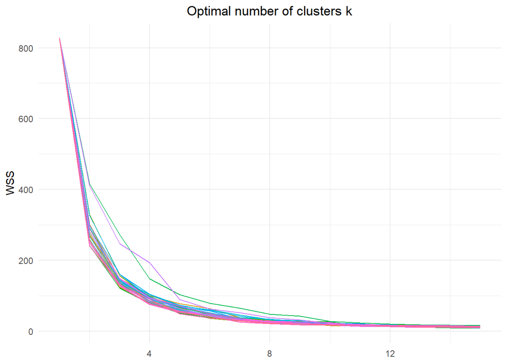

```r
CERES.red_Optimal_K <- function(ceres.red.genes, specifier) {
  output <- lapply(1:ncol(ceres.red.genes), function(a){
    df <- scale(ceres.red.genes[,a]) # pick one column of input data and scale
    wss <-(nrow(df-1))*sum(apply(df,2,var)) #define method of wss computation
    for (i in 2:15){ # for k between 2 and 15
      set.seed(1234) # to ensure reproducability of results
      wss[i] <- sum(kmeans(df, centers = i)$withinss)
    }
    return(wss)
  })
  names (output) <- colnames(ceres.red.genes) # rename the output
  return(output)
}

Ceres.red_optKS <- CERES.red_Optimal_K(ceres.red.genes, "CERES Optimal Clusters k")
## plotting wss function
optimalKprocessedData.red <- lapply(seq_along(Ceres.red_optKS), function(a){
  dtPicker <- as.data.frame(Ceres.red_optKS[[a]]) # one vector picked and formatted into dataframe
  dtPicker$Cell_Sample <- names(Ceres.red_optKS)[a] #sample added as label
  dtPicker$OptimalK <- 1:nrow(dtPicker)
  return(dtPicker)
})

optimalKprocessedData.red <- as.data.frame(do.call("rbind",optimalKprocessedData.red)) # output into dataframe
colnames(optimalKprocessedData.red) <- c("WSS", "Cell_Sample", "OptimalK") # renaming columns

## using ggplot to plot output
ggplot(data = optimalKprocessedData.red, aes(x=OptimalK, y=WSS)) +
  geom_line(aes(color=Cell_Sample)) +
  labs(title = 'Optimal number of clusters k', x = 'Number of clusters', y = 'WSS') +
  theme_minimal() +
  theme(legend.position ='none',
        plot.title = element_text(hjust = 0.5),
        axis.text.x = element_text(angle = 0, vjust = 0, hjust=0.5),
        legend.title= element_blank(),
        axis.title.x = element_blank(),
        strip.text.y = element_text(angle = 0))
```

Looking at the “kink”, this method suggested using two or three cluster centres for clustering: WSS should be minimized without creating unnecessarily many clusters. So clustering plots as well as the respective silhouette graphs allow for better decision making on what to choose.

```r
km2.red = kmeans(x= ceres.red.genes, centers = 2, nstart = 100)
km3.red = kmeans(x = ceres.red.genes, centers = 3, nstart = 100)

p2.red = fviz_cluster(km2.red, geom = "point", data = ceres.red.genes, pointsize = 0.5) + ggtitle("k = 2")
p3.red = fviz_cluster(km3.red, geom = "point", data = ceres.red.genes, pointsize = 0.5) + ggtitle("k = 3")

sum2.red = summary(silhouette(km2.red$cluster, dist(ceres.red.genes)))
s2.red = fviz_silhouette(silhouette(km2.red$cluster, dist(ceres.red.genes), do.clus.stat = TRUE), border = NA, main = "Silhouette values for 2 clusters") +
  xlab(paste0("Average silhouette value: ", round(sum2.red$avg.width, digits = 2)))
```

```
##   cluster size ave.sil.width
## 1       1   81          0.49
## 2       2  747          0.73
```

```r
sum3.red = summary(silhouette(km3.red$cluster, dist(ceres.red.genes)))
s3.red = fviz_silhouette(silhouette(km3.red$cluster, dist(ceres.red.genes), do.clus.stat = TRUE), border = NA, main = "Silhouette values for 3 clusters")+
  xlab(paste0("Average silhouette value: ", round(sum3.red$avg.width, digits = 2)))
```

```
##   cluster size ave.sil.width
## 1       1   75          0.43
## 2       2  341          0.25
## 3       3  412          0.33
```

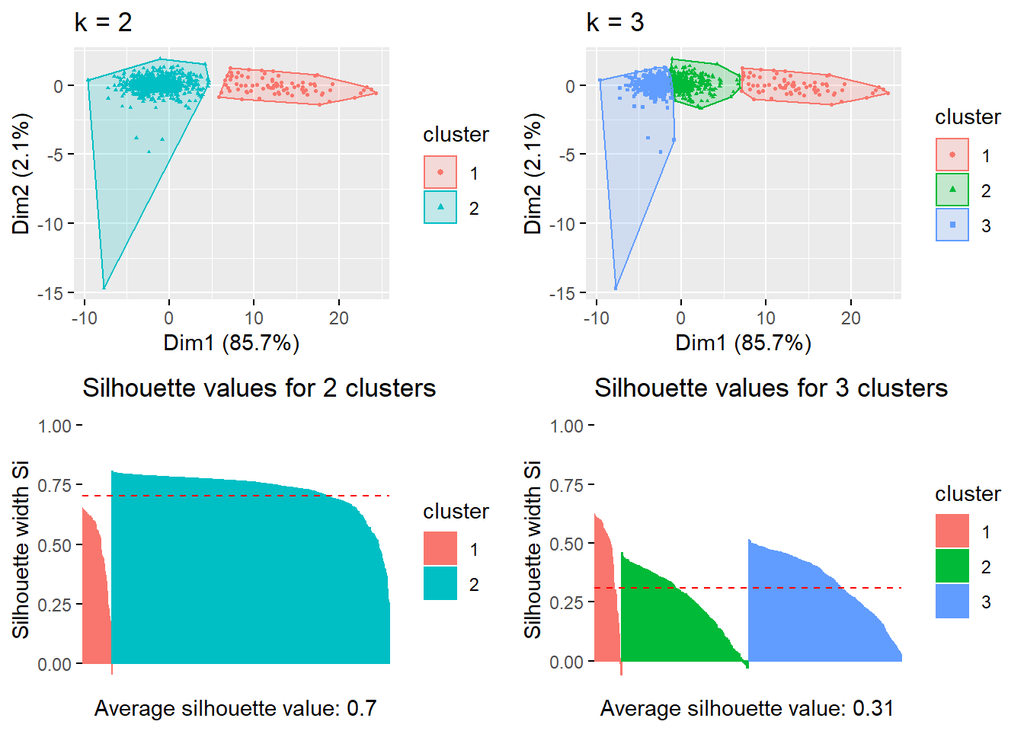

```r
grid.arrange(p2.red,p3.red,s2.red,s3.red, nrow=2)
```

The silhouette values as well as the clustering plot for k = 2 show less wrongly assigned data points (evident by the small red bar going below Si = 0) as well as a more distinct clustering in comparison to k = 3. Hence using 2 centroids proves to be more optimal.

Goal of k means clustering is grouping of objects with similar values (here the CERES score) together in one specific cluster. Potential SSTs as well as our selected driver mutations should therefore be part of the same cluster. TP53, PTEN and MUC-16 are all part of cluster 2, so potential SSTs which belong to cluster 1 are removed. We clustered our reduced data as described above and found the following potential SSTs in the same clusters as the DMs:

TP53

```r
genes.clusters = as.data.frame(km2.red$cluster)
genes.clusters$rownames = rownames(genes.clusters)
sst.genes.clusters.tp53 = genes.clusters[-(which(rownames(genes.clusters) %!in% rownames(SST.tp53))),]
sst.genes.p.clusters.tp53 = cbind(sst.genes.clusters.tp53, SST.tp53)
sst.genes.p.clusters.tp53 = sst.genes.p.clusters.tp53[, -2]
colnames(sst.genes.p.clusters.tp53) = c("Cluster", "Correlation to TP53")
sst.genes.p.clusters.tp53 = sst.genes.p.clusters.tp53[-which((sst.genes.p.clusters.tp53$Cluster) == 1),]
rownames(sst.genes.p.clusters.tp53)
```

```
##   [1] "ABHD17B"  "ACSM1"    "AKR7A2"   "ALOX15"   "C15orf65" "C1orf53"
##   [7] "C3orf67"  "CHD9"     "CLDN5"    "CNBD1"    "CNTN3"    "CNTNAP5"
##  [13] "CNTRL"    "DAAM1"    "DCHS1"    "DCLRE1A"  "DCP1B"    "DENND4A"
##  [19] "DHX29"    "DNAH1"    "DOCK8"    "DSC1"     "DUOX2"    "DYSF"
##  [25] "DZIP3"    "E2F7"     "EIF4G3"   "ELAVL2"   "EPB41L3"  "ETV1"
##  [31] "FAM160A2" "FAM160B1" "FAM161A"  "FAM161B"  "FAM208B"  "FBXW5"
##  [37] "FNDC3B"   "FOXN3"    "GABRA5"   "GCNT2"    "GGCX"     "HCFC2"
##  [43] "HELZ"     "HPSE2"    "INO80E"   "KCNQ1"    "KIAA0100" "KLK11"
##  [49] "KRT31"    "KRT39"    "L3MBTL3"  "LCP2"     "LMBRD1"   "LRRC72"
##  [55] "LRWD1"    "LTN1"     "MLH1"     "MLXIPL"   "MOV10"    "MROH7"
##  [61] "MTHFS"    "MTUS1"    "MYO1A"    "MYO5C"    "NAA16"    "NCOA2"
##  [67] "NDST4"    "NIPA2"    "NLRC5"    "NOG"      "OR11G2"   "OXNAD1"
##  [73] "PCDH7"    "PCNT"     "PDGFB"    "PIK3C2G"  "PILRA"    "PLEC"
##  [79] "PPFIA2"   "PREX2"    "PTGDR2"   "PTPRC"    "PTPRF"    "RAB19"
##  [85] "RABL2B"   "RTKN2"    "SACS"     "SCN3A"    "SERPINF1" "SERPINI2"
##  [91] "SH3D21"   "SLAMF9"   "SLC16A5"  "SLC27A6"  "SLC44A4"  "SLC5A7"
##  [97] "SLC6A9"   "SLCO2A1"  "SMARCA4"  "SUPT20H"  "SUSD2"    "TAOK1"
## [103] "TAS2R39"  "TCF12"    "TMEM133"  "TMEM215"  "TRIM9"    "TTC21A"
## [109] "UBXN1"    "UBXN6"    "UCK2"     "UGT1A5"   "UGT2B7"   "USH1G"
## [115] "VAT1L"    "ZMIZ2"    "ZNF189"   "ZNF397"   "ZNF705G"  "ZPLD1"
```

PTEN:

```r
genes.clusters = as.data.frame(km2.red$cluster)
genes.clusters$rownames = rownames(genes.clusters)
sst.genes.clusters.pten = genes.clusters[-(which(rownames(genes.clusters) %!in% rownames(SST.pten))),]
sst.genes.p.clusters.pten = cbind(sst.genes.clusters.pten, SST.pten)
sst.genes.p.clusters.pten = sst.genes.p.clusters.pten[, -2]
colnames(sst.genes.p.clusters.pten) = c("Cluster", "Correlation to PTEN")
sst.genes.p.clusters.pten = sst.genes.p.clusters.pten[-which((sst.genes.p.clusters.pten$Cluster) == 1),]
rownames(sst.genes.p.clusters.pten)
```

```
##  [1] "ADM"      "ANO4"     "AP3B2"    "ARHGEF5"  "ARID2"    "ATAD5"
##  [7] "ATRNL1"   "BAZ2B"    "BRIP1"    "BTBD11"   "C5orf38"  "CACNA1I"
## [13] "CCDC73"   "CDKN2A"   "CDKN2C"   "CGRRF1"   "COL11A1"  "COX6A1"
## [19] "CPNE5"    "CSTA"     "CTSZ"     "DAPK1"    "DNAI1"    "DTX3"
## [25] "E2F7"     "ENPP3"    "EYS"      "FAM161B"  "FPR1"     "GCLC"
## [31] "GDF9"     "GDPD4"    "GDPD5"    "GIGYF2"   "GNAI1"    "GPATCH4"
## [37] "HCLS1"    "HIST1H1T" "IL5"      "INO80E"   "ITGA10"   "KBTBD3"
## [43] "KIAA0100" "KIF27"    "LUZP1"    "MFSD6"    "MYO15A"   "MYOC"
## [49] "OR2T6"    "OR56A4"   "OR5M8"    "PDE11A"   "PDGFC"    "PHLDB3"
## [55] "PPAT"     "PPL"      "PPP1R26"  "PPP1R3C"  "PTER"     "RNF219"
## [61] "RSRC1"    "SACS"     "SALL1"    "SAMD9L"   "SCN3A"    "SH3D21"
## [67] "SLA2"     "SPAG1"    "SPATA6"   "SSH2"     "TACC1"    "TDP2"
## [73] "TDRD7"    "TMEM209"  "TRAPPC9"  "TRIP12"   "UCK2"     "UGT2B4"
## [79] "USH1G"    "VPS13A"   "ZMYM5"    "ZNF184"   "ZNF300"   "ZNF436"
## [85] "ZNF597"   "ZNF609"   "ZNF644"   "ZNF780B"  "ZNF83"
```

MUC-16:

```r
genes.clusters = as.data.frame(km2.red$cluster)
genes.clusters$rownames = rownames(genes.clusters)
sst.genes.clusters.muc16 = genes.clusters[-(which(rownames(genes.clusters) %!in% rownames(SST.muc16))),]
sst.genes.p.clusters.muc16 = cbind(sst.genes.clusters.muc16, SST.muc16)
sst.genes.p.clusters.muc16 = sst.genes.p.clusters.muc16[, -2]
colnames(sst.genes.p.clusters.muc16) = c("Cluster", "Correlation to MUC-16")
sst.genes.p.clusters.muc16 = sst.genes.p.clusters.muc16[-which((sst.genes.p.clusters.muc16$Cluster) == 1),]
rownames(sst.genes.p.clusters.muc16)
```

```
##  [1] "ABCB9"    "ADAMTSL3" "ADD1"     "ARID2"    "ARMC1"    "CACNA1G"
##  [7] "CCDC148"  "CCDC88B"  "CDH20"    "CEP290"   "CIB2"     "CNTNAP5"
## [13] "COL11A1"  "DHX29"    "DLGAP2"   "DOCK9"    "E2F7"     "ENO3"
## [19] "ENPP3"    "FAM160A2" "FAM161B"  "FAM208B"  "FDCSP"    "FOXN3"
## [25] "GIGYF2"   "GNB4"     "GPRIN3"   "HAPLN3"   "HAX1"     "HCFC2"
## [31] "IBTK"     "IL5"      "IMPA1"    "JPH4"     "KIAA0100" "LCN15"
## [37] "MACC1"    "MMAB"     "MYO15A"   "MYO5C"    "NUCKS1"   "OR11G2"
## [43] "OR2A7"    "OR52I2"   "OR5M8"    "PDIA3"    "PHC3"     "PIK3C2G"
## [49] "PIWIL3"   "PM20D1"   "PTER"     "PTPN13"   "RTN2"     "RYR3"
## [55] "SGCD"     "SIRT1"    "SLC12A2"  "SLC34A1"  "SLC44A4"  "STK11"
## [61] "TAOK1"    "TAS2R39"  "TDP2"     "TPSAB1"   "TRIM24"   "TTC8"
## [67] "UGT2B28"  "WDR27"    "WDR36"    "ZNF254"   "ZPLD1"
```

In this step we excluded the potential SSTs that do not cluster together with the corresponding DM based on the CERES scores of these genes in order to further reduce the number of potential SSTs based on their likelihood. We need to pay attention to the circumstance that the chance of putting a gene into the wrong cluster is 50 % when 2 centers are used. The probability of wrong clustering is smaller if we used more centers. Based on our silhouette plot the optimal k seems to be 2, because there were less negative silhouette values compared to the clustering that was performed using 3 centers. Clustering with 2 centers also lead to 2 clearly distinct clusters. When we performed the k means clustering using 3 centers, the result were two clusters that were very close and the separation was not as distinct. For this reason we chose to perform our k-means with 2 centers. A potential problem is that the TP53 is located very distant from all other data points. This affects the used method to determine the optimal number of k through WSS. WSS makes the assumption that clusters are convex and isotropic, which is not always the case. This method responds poorly to elongated clusters or manifolds with irregular shapes.

## Conclusion

Clustering of the CERES scores of all genes mutated in cell lines containing at least one of TP53, MUC-16 or PTEN, led to 2 distinct clusters with TP53 as an evident outlier. K-Means allowed to further reduce our set of possible SSTs to more accurately represent viable targets. As already stated above though, none of the SSTs identified in our subset of cell lines were found in current research.

# Multiple linear regression

## Creating a model

With a multiple linear regression we intended to create a model which could predict a SST deriving from a DM. This turned out not to work and we decided to create a model for each expression, copy number, CERES score and probability, each based on the other values.

We calculated the mean of expression, copy number, CERES score and probability throughout all cell lines and combined all values into one matrix. We then performed the multiple linear regression.

```r
mlr.mat = as.data.frame(cbind(rowMeans(exp.clean.w0), rowMeans(copy.clean.w0), rowMeans(ceres.clean.w0), rowMeans(prob.clean.w0)))
colnames(mlr.mat) = c("expression", "copynumber", "ceres", "probability")

summary(lm(expression ~ ., data = mlr.mat))
```

```
##
## Call:
## lm(formula = expression ~ ., data = mlr.mat)
##
## Residuals:
##     Min      1Q  Median      3Q     Max
## -5.5384 -1.3249  0.0093  1.2134  8.4400
##
## Coefficients:
##             Estimate Std. Error t value Pr(>|t|)
## (Intercept)  3.58891    0.02216 161.932  < 2e-16 ***
## copynumber   0.50033    0.08393   5.962 2.57e-09 ***
## ceres       -0.36131    0.21919  -1.648   0.0993 .
## probability  2.40258    0.23924  10.042  < 2e-16 ***
## ---
## Signif. codes:  0 '***' 0.001 '**' 0.01 '*' 0.05 '.' 0.1 ' ' 1
##
## Residual standard error: 1.867 on 11541 degrees of freedom
## Multiple R-squared:  0.1565, Adjusted R-squared:  0.1563
## F-statistic: 713.7 on 3 and 11541 DF,  p-value: < 2.2e-16
```

```r
summary(lm(copynumber ~ ., data = mlr.mat))
```

```
##
## Call:
## lm(formula = copynumber ~ ., data = mlr.mat)
##
## Residuals:
##      Min       1Q   Median       3Q      Max
## -10.6636  -0.0950  -0.0004   0.0858   0.9718
##
## Coefficients:
##              Estimate Std. Error t value Pr(>|t|)
## (Intercept) -0.011066   0.004439  -2.493   0.0127 *
## expression   0.006136   0.001029   5.962 2.57e-09 ***
## ceres       -0.032267   0.024274  -1.329   0.1838
## probability -0.035752   0.026608  -1.344   0.1791
## ---
## Signif. codes:  0 '***' 0.001 '**' 0.01 '*' 0.05 '.' 0.1 ' ' 1
##
## Residual standard error: 0.2067 on 11541 degrees of freedom
## Multiple R-squared:  0.003696,   Adjusted R-squared:  0.003437
## F-statistic: 14.27 on 3 and 11541 DF,  p-value: 2.797e-09
```

```r
summary(lm(ceres ~ ., data = mlr.mat))
```

```
##
## Call:
## lm(formula = ceres ~ ., data = mlr.mat)
##
## Residuals:
##      Min       1Q   Median       3Q      Max
## -0.61500 -0.04951 -0.01382  0.04486  0.43352
##
## Coefficients:
##               Estimate Std. Error  t value Pr(>|t|)
## (Intercept)  0.0344542  0.0016719   20.608   <2e-16 ***
## expression  -0.0006515  0.0003952   -1.648   0.0993 .
## copynumber  -0.0047442  0.0035690   -1.329   0.1838
## probability -1.0537464  0.0028102 -374.972   <2e-16 ***
## ---
## Signif. codes:  0 '***' 0.001 '**' 0.01 '*' 0.05 '.' 0.1 ' ' 1
##
## Residual standard error: 0.07927 on 11541 degrees of freedom
## Multiple R-squared:  0.9353, Adjusted R-squared:  0.9352
## F-statistic: 5.558e+04 on 3 and 11541 DF,  p-value: < 2.2e-16
```

```r
summary(lm(probability ~ ., data = mlr.mat))
```

```
##
## Call:
## lm(formula = probability ~ ., data = mlr.mat)
##
## Residuals:
##      Min       1Q   Median       3Q      Max
## -0.49446 -0.04828 -0.01813  0.03675  0.37130
##
## Coefficients:
##              Estimate Std. Error  t value Pr(>|t|)
## (Intercept)  0.027691   0.001532   18.081   <2e-16 ***
## expression   0.003606   0.000359   10.042   <2e-16 ***
## copynumber  -0.004375   0.003256   -1.344    0.179
## ceres       -0.877009   0.002339 -374.972   <2e-16 ***
## ---
## Signif. codes:  0 '***' 0.001 '**' 0.01 '*' 0.05 '.' 0.1 ' ' 1
##
## Residual standard error: 0.07232 on 11541 degrees of freedom
## Multiple R-squared:  0.9358, Adjusted R-squared:  0.9358
## F-statistic: 5.608e+04 on 3 and 11541 DF,  p-value: < 2.2e-16
```

To evaluate our model we looked at the R-squared value. R squared is a statistical measure of how close the data are to the fitted regression line. It is also known as the coefficient of multiple determination for multiple linear regression.

The definition of R-squared is the percentage of the response variable variation that is explained by a linear model. It is always between 0 and 1. 0 means that the model explains none of the variability around its mean and 1 indicates that the model explains all the variability of the response data around its mean.

expression: r<sup>2</sup> = 0.1563  
copynumber: r<sup>2</sup> = 0.003437  
CERES-score: r<sup>2</sup> = 0.9352  
probability: r<sup>2</sup> = 0.9358

As we can see, the models for expression and copy number do not look promising, having a R-squared value of 0.1563 and 0,0034. The models for CERES score and probability look more reliable with values of 0.9352 and 0.9358.

## Training and testing our multiple linear regression model

Packages: caTools

The aim with this testing was to use values the model had never seen before and to compare them with the real values.

First we split the multiple linear regression matrix into 4/5 training set and 1/5 testing set.

```r
library(caTools)
set.seed(123) #initialize the random numbers
split.exp = sample.split(mlr.mat$expression, SplitRatio = 0.8) #split the mlr.mat into 4/5 Training and 1/5 Testing expression values
split.exp = as.data.frame(split.exp) #converting split.exp to a data frame for further analysis
training_set_exp = subset(mlr.mat, split.exp == TRUE) #use labels to get training data
test_set_exp = subset(mlr.mat, split.exp == FALSE) #dim(test_set_exp) will give you 2309 --> 11545/5*1 = 2309 --> train/test split worked

#for copy number model
set.seed(123)
split.copy = sample.split(mlr.mat$copynumber, SplitRatio = 0.8)
split.copy = as.data.frame(split.copy)
training.set.copy = subset(mlr.mat, split.copy == TRUE)
test.set.copy = subset(mlr.mat, split.copy == FALSE)
#dimensions were not right. Explanation below.

#for ceres model
set.seed(123)
split.ceres = sample.split(mlr.mat$ceres, SplitRatio = 0.8)
training.set.ceres = subset(mlr.mat, split.ceres == TRUE)
test.set.ceres = subset(mlr.mat, split.ceres == FALSE)

#for probability model
set.seed(123)
split.prob = sample.split(mlr.mat$probability, SplitRatio = 0.8)
training.set.prob = subset(mlr.mat, split.prob ==TRUE)
test.set.prob = subset(mlr.mat, split.prob == FALSE)
```

Observation: the training/test set splitting did not work for the copy number matrix. The dimensions of the test set were not right. We had 2021 values instead of the 2309 we needed, which represent one fifth of the original multiple linear regression matrix.

We then fitted the multiple linear regression to the training set.

```r
exp.regressor = lm(expression ~ ., data = training_set_exp)
ceres.regressor = lm(ceres ~ ., data = as.data.frame(training.set.ceres))
prob.regressor = lm(probability ~., data = as.data.frame(training.set.prob))
copy.regressor = lm(copynumber ~., data = training.set.copy)
```

Then we predicted the test results based on data that our model had never seen before. This is very useful to evaluate the performance of the model.

```r
exp_pred = predict(exp.regressor, newdata = test_set_exp)
test_set_exp$Prediction = exp_pred #add predictions to mlr.mat
#now a comparison of the Predictions (last column) with the real values for the expression (1st column) is possible

ceres_pred = predict(ceres.regressor, newdata = test.set.ceres)
test.set.ceres$Prediction = ceres_pred

prob_pred = predict(prob.regressor, newdata = test.set.prob)
test.set.prob$Prediction = prob_pred

copy.pred = predict(copy.regressor, newdata = test.set.copy)
test.set.copy$Prediction = copy.pred
```

## Visualizing real values against test values

To better visualize and evaluate our models we plotted the predicted values against the real values for expression,copy number, CERES score and probability

**For the expression model:**

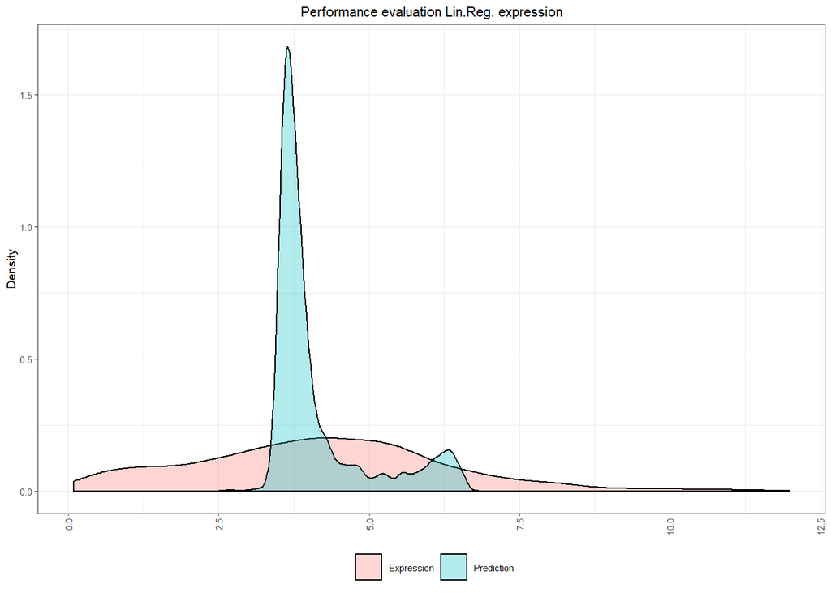

```r
plot.exp.m <- melt(test_set_exp$expression)
a <- melt(test_set_exp$Prediction)
colnames(plot.exp.m) <- "Expression"
rownames(plot.exp.m) = rownames(test.set.ceres)
colnames(a) <- "Prediction"
plot.exp.m <- cbind(plot.exp.m,a)
plottingData.exp <- melt(plot.exp.m)
exp_plot <- ggplot(data = plottingData.exp, aes(x=value, fill=variable)) +
  geom_density(alpha=.3) +
  ggtitle(paste0("Performance evaluation Lin.Reg. expression")) +
  ylab("Density") +
  xlab("Expression values") +
  theme_bw(base_size = 7) +
  theme(legend.position="bottom",
        legend.direction="horizontal",
        plot.title = element_text(hjust = 0.5),
        axis.text.x = element_text(angle = 90, vjust = 0.5, hjust=1),
        legend.title= element_blank(),
        axis.title.x = element_blank(),
        strip.text.y = element_text(angle = 0))

exp_plot
```

We see that the predicted values and the real values do not match. This was already expected judging by the R-squared value our model gave us. We cannot use our model to predict expressions values.

**For the copy number model:**

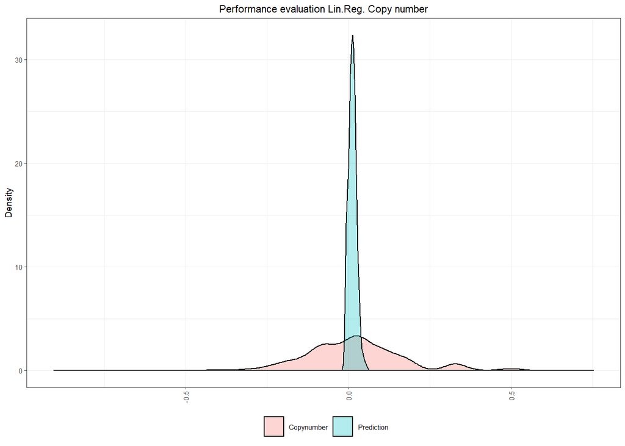

```r
plot.copy.m <- melt(test.set.copy$copynumber)
a <- melt(test.set.copy$Prediction)
colnames(plot.copy.m) <- "Copynumber"
rownames(plot.copy.m) = rownames(test.set.copy)
colnames(a)<- "Prediction"
plot.copy.m <- cbind(plot.copy.m,a)
plottingData.copy <- melt(plot.copy.m)
copy_plot <- ggplot(data = plottingData.copy, aes(x=value, fill=variable)) +
  geom_density(alpha=.3) +
  ggtitle(paste0("Performance evaluation Lin.Reg. Copy number")) +
  ylab("Density") +
  xlab("Copy number values") +
  theme_bw(base_size = 7) +
  theme(legend.position="bottom",
        legend.direction="horizontal",
        plot.title = element_text(hjust = 0.5),
        axis.text.x = element_text(angle = 90, vjust = 0.5, hjust=1),
        legend.title= element_blank(),
        axis.title.x = element_blank(),
        strip.text.y = element_text(angle = 0))

copy_plot
```

Looking at the graph we see that the predicted and real values do not match. This was expected judging by the R-squared values for the copy number prediction model. Our model is not suitable for a prediction of gene copy numbers.

**For the CERES score model:**

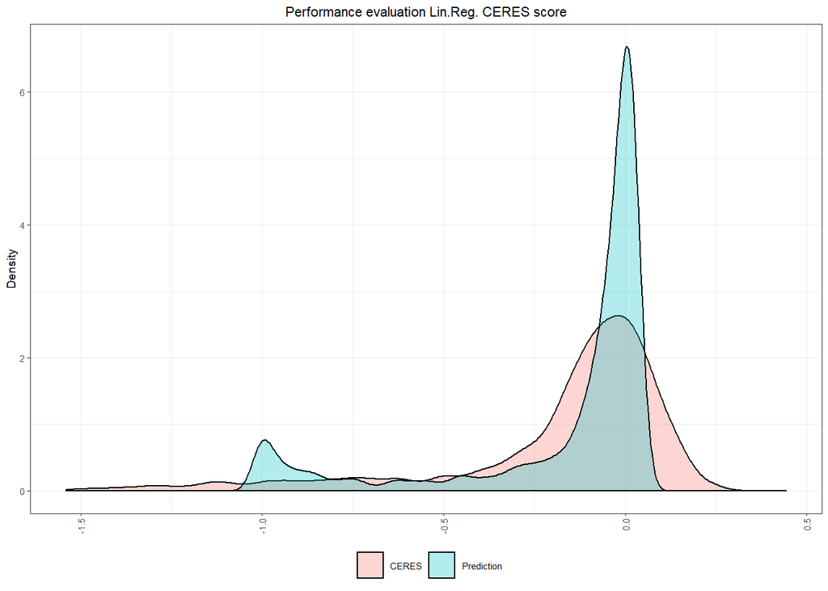

```r
plot.ceres.m <- melt(test.set.ceres$ceres)
a <- melt(test.set.ceres$Prediction)
colnames(plot.ceres.m) <- "CERES"
rownames(plot.ceres.m) = rownames(test.set.ceres)
colnames(a) <- "Prediction"
plot.ceres.m <- cbind(plot.ceres.m,a)
plottingData.ceres <- melt(plot.ceres.m)
ceres_plot <- ggplot(data = plottingData.ceres, aes(x=value, fill=variable)) +
  geom_density(alpha=.3) +
  ggtitle(paste0("Performance evaluation Lin.Reg. CERES score")) +
  ylab("Density") +
  xlab("CERES score values") +
  theme_bw(base_size = 7) +
  theme(legend.position="bottom",
        legend.direction="horizontal",
        plot.title = element_text(hjust = 0.5),
        axis.text.x = element_text(angle = 90, vjust = 0.5, hjust=1),
        legend.title= element_blank(),
        axis.title.x = element_blank(),
        strip.text.y = element_text(angle = 0))

ceres_plot
```

The R-squared value for the CERES score model was very promising, but judging by the visualization it is not reliable. Both real and predicted values peak in the same region, around 0.0, but they have very different densities and do not match.

**For the probability model:**

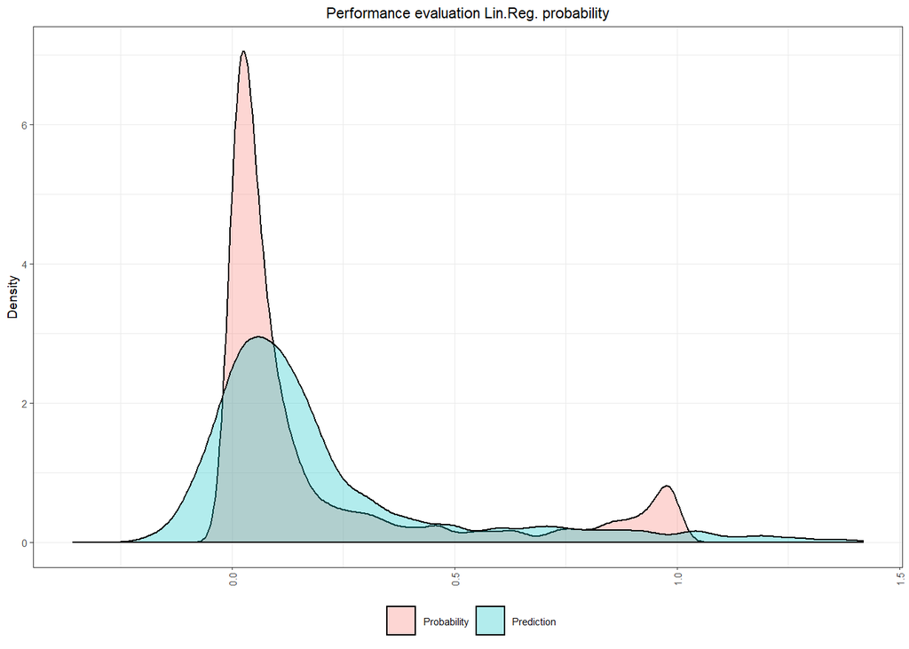

```r
library(reshape2)
library(ggplot2)
plot.prob.m <- melt(test.set.prob$probability)
a <- melt(test.set.prob$Prediction)
colnames(plot.prob.m) <- "Probability"
rownames(plot.prob.m) = rownames(test.set.prob)
colnames(a) <- "Prediction"
plot.prob.m <- cbind(plot.prob.m,a)
plottingData.prob <- melt(plot.prob.m)
prob_plot <- ggplot(data = plottingData.prob, aes(x=value, fill=variable)) +
    geom_density(alpha=.3) +
     ggtitle(paste0("Performance evaluation Lin.Reg. probability")) +
     ylab("Density") +
     xlab("Probability values") +
    theme_bw(base_size = 7) +
     theme(legend.position="bottom",
           legend.direction="horizontal",
           plot.title = element_text(hjust = 0.5),           axis.text.x = element_text(angle = 90, vjust = 0.5, hjust=1),
           legend.title= element_blank(),
           axis.title.x = element_blank(),
           strip.text.y = element_text(angle = 0))

prob_plot
```

Looking at both curves we see the same problem we had with the CERES score model. The R-squared value looked promising but after training and testing our model, the result was not what we aimed for. The curves show that the predicted and real values are not similar, which proves our model to be not that good.

## Conclusion

As stated previously, the goal was to create a model that could predict one of our four variables using all three others (between expression, copynumber, CERES score and probability matrices). Our models proved not to be useful or efficient in the prediction, especially for copy number and expression. This has to do with the fact that the expression is an important value and does not depend on the other values, e.g. CERES score or probability. The models for the prediction of the CERES score and probability looked promising because of the R-squared values, but after the visualisation of the predicted versus the real values, we can say that they are not suitable for a correct prediction.

# Final conclusions

Performing our data analysis we identified that three out of the six most common mutations across our cell lines were directly associated with cancer development (TP53, MUC-16 & PTEN). Two of those, TP53 and PTEN, are prominent genetic alterations in GBM.

Using the aforementioned mutations as driving mutations (DMs), we performed Shapiro-Wilk-Tests and used Spearman correlation to determine whether there are dependencies between the presence of a specific driving mutation and the essentiality for cell survival of another mutated gene. For each DM around 100 SSTs were found, none of which could be supported by scientific papers.

We could not assign our cell lines to a specific subtype of GBM. We would assign them more to the proneural or mesenchymal GBM subtypes, because of their specific markers, TP53 and PTEN. However, these were the only known markers for these two subtypes that we could identify in our cell lines.

Proceeding with the k-means clustering, we found that by the clustering of the CERES scores of all genes mutated in our cell lines containing at least one of our DMs, led to two distinct clusters. This method allowed us to further reduce our set of possible second site targets (SSTs), but none could be found in current research.

We also did a multiple linear regression to create models to try and predict one of our four variables using all other three as a base. They proved not to be efficient for a prediction judging by the visualization. We expected the values for expression and copy number to be hardly predictable because these are such independent variables. The results for CERES score and probability were more pleasing.

All in all, we did not find definite SSTs but did find possible targets that could be further researched with a bigger range of data and other cell lines, in order to confirm if they are indeed SSTs.

# References

- Brennan, C.W., Verhaak, R.G.W., McKenna, A., Campos, B., Noushmehr, H., Salama, S.R., Zheng, S., Chakravarty, D., Sanborn, J.Z., Berman, S.H., et al. (2013). The somatic genomic landscape of glioblastoma. Cell 155, 462-477.
- Cantley, L.C., and Neel, B.G. (1999). New insights into tumor suppression: PTEN suppresses tumor formation by restraining the phosphoinositide 3-kinase/AKT pathway. Proc Natl Acad Sci U S A 96, 4240-4245.
- Carossa, V., Ghelli, A., Tropeano, C.V., Valentino, M.L., Iommarini, L., Maresca, A., Caporali, L., La Morgia, C., Liguori, R., Barboni, P., et al. (2014). A Novel in-Frame 18-bp Microdeletion in MT-CYB Causes a Multisystem Disorder with Prominent Exercise Intolerance. Human Mutation 35, 954-958.
- Ceyhan-Birsoy, O., Agrawal, P.B., Hidalgo, C., Schmitz-Abe, K., DeChene, E.T., Swanson, L.C., Soemedi, R., Vasli, N., Iannaccone, S.T., Shieh, P.B., et al. (2013). Recessive truncating titin gene, TTN, mutations presenting as centronuclear myopathy. Neurology 81, 1205-1214.
- Chen, P., Zhao, D., Li, J., Liang, X., Li, J., Chang, A., Henry, V.K., Lan, Z., Spring, D.J., Rao, G., et al. (2019). Symbiotic Macrophage-Glioma Cell Interactions Reveal Synthetic Lethality in PTEN-Null Glioma. Cancer Cell 35, 868-884.e866.
- Gerull, B., Gramlich, M., Atherton, J., McNabb, M., Trombitás, K., Sasse-Klaassen, S., Seidman, J.G., Seidman, C., Granzier, H., Labeit, S., et al. (2002). Mutations of TTN, encoding the giant muscle filament titin, cause familial dilated cardiomyopathy. Nature Genetics 30, 201-204.
- Masica, D.L., and Karchin, R. (2011). Correlation of somatic mutation and expression identifies genes important in human glioblastoma progression and survival. Cancer Res 71, 4550-4561.
- McKenzie, M., and Duchen, M.R. (2016). Impaired Cellular Bioenergetics Causes Mitochondrial Calcium Handling Defects in MT-ND5 Mutant Cybrids. PLOS ONE 11, e0154371.
- Mereniuk, T.R., El Gendy, M.A.M., Mendes-Pereira, A.M., Lord, C.J., Ghosh, S., Foley, E., Ashworth, A., and Weinfeld, M. (2013). Synthetic lethal targeting of PTEN-deficient cancer cells using selective disruption of polynucleotide kinase/phosphatase. Mol Cancer Ther 12, 2135-2144.
- Noushmehr, H., Weisenberger, D.J., Diefes, K., Phillips, H.S., Pujara, K., Berman, B.P., Pan, F., Pelloski, C.E., Sulman, E.P., Bhat, K.P., et al. (2010). Identification of a CpG island methylator phenotype that defines a distinct subgroup of glioma. Cancer cell 17, 510-522.
- Scholler, N., and Urban, N. (2007). CA125 in ovarian cancer. Biomark Med 1, 513-523.
- Szczurek, E., Misra, N., and Vingron, M. (2013). Synthetic sickness or lethality points at candidate combination therapy targets in glioblastoma. International Journal of Cancer 133, 2123-2132.
- Takami, H., Yoshida, A., Fukushima, S., Arita, H., Matsushita, Y., Nakamura, T., Ohno, M., Miyakita, Y., Shibui, S., Narita, Y., et al. (2015). Revisiting TP53 Mutations and Immunohistochemistry—A Comparative Study in 157 Diffuse Gliomas. Brain Pathology 25, 256-265.
- The Cancer Genome Atlas Research, N., McLendon, R., Friedman, A., Bigner, D., Van Meir, E.G., Brat, D.J., M. Mastrogianakis, G., Olson, J.J., Mikkelsen, T., Lehman, N., et al. (2008). Comprehensive genomic characterization defines human glioblastoma genes and core pathways. Nature 455, 1061.
- Verhaak, R.G.W., Hoadley, K.A., Purdom, E., Wang, V., Qi, Y., Wilkerson, M.D., Miller, C.R., Ding, L., Golub, T., Mesirov, J.P., et al. (2010). Integrated genomic analysis identifies clinically relevant subtypes of glioblastoma characterized by abnormalities in PDGFRA, IDH1, EGFR, and NF1. Cancer cell 17, 98-110.
- Zhou, N., Tang, L., Jiang, Y., Qin, S., Cui, J., Wang, Y., Zhu, W., Zhao, W., Pan, C., and Shu, X. (2019). Whole-exome sequencing reveals a novel mutation of MT-ND5 gene in a mitochondrial cardiomyopathy pedigree: Patients who show biventricular hypertrophy, hyperlactacidemia, pulmonary hypertension, and decreased exercise tolerance. Anatol J Cardiol 21, 18-24.